# ds202_lab3

Patrick Origer

9/25/2020

```r
#install.packages('readxl')
#library('readx1')
dat <- readxl::read_xls('extract.xls')
dat
```

```
## # A tibble: 64,816 x 9
##    `Gss year for t~ `Respondent id ~ `Marital status` `Highest year o~
##               <dbl>            <dbl> <chr>            <chr>
##  1             1972                1 Never married    16
##  2             1972                2 Married          10
##  3             1972                3 Married          12
##  4             1972                4 Married          17
##  5             1972                5 Married          12
##  6             1972                6 Never married    14
##  7             1972                7 Divorced         13
##  8             1972                8 Never married    16
##  9             1972                9 Never married    12
## 10             1972               10 Married          12
## # ... with 64,806 more rows, and 5 more variables: `Respondents sex` <chr>,
## #   `Respondents income` <chr>, `Political party affiliation` <chr>, `General
## #   happiness` <chr>, `Ballot used for interview` <chr>
```

```r
library(ggplot2)
library(dplyr)
dat <- rename(dat, 'Year' = 'Gss year for this respondent', 'ID' = 'Respondent id number', 'MS' = 'Marital status', 'Education' = 'Highest year of school completed', 'Sex' = 'Respondents sex', 'Income' = 'Respondents income', 'Affiliation' = 'Political party affiliation', 'Happiness' = 'General happiness', 'Ballot' = 'Ballot used for interview')
```

```r
dat$EducationYears <- as.numeric(dat$Education)
AffEduMean <- dat %>% group_by(Affiliation) %>%
  summarise(meanEducation = mean(EducationYears, na.rm=TRUE)) %>%
  arrange(desc(meanEducation))
AffEduMedian <- dat %>% group_by(Affiliation) %>%
  summarise(medianEducation = median(EducationYears, na.rm=TRUE)) %>%
  arrange(desc(medianEducation))
AffEduMean
```

```
## # A tibble: 11 x 2
##    Affiliation        meanEducation
##    <chr>                      <dbl>
##  1 Strong republican           13.4
##  2 Other party                 13.4
##  3 Ind,near rep                13.3
##  4 Not str republican          13.3
##  5 Ind,near dem                13.2
##  6 Not str democrat            12.6
##  7 Strong democrat             12.5
##  8 Independent                 12.3
##  9 No answer                   12.3
## 10 Don't know                  10.9
## 11 <NA>                       NaN
```

```r
dat <- full_join(dat, AffEduMedian, by='Affiliation')
```

1. It seems that picking or at least leaning to a political party is more typical of people with more years of education. Independent and Don’t know are two of the lowest Affiliations. Those two affiliations don’t pick or lean to any side politically, so it seems that people that answer the same way are more likely to have less years of education than people of other more political affiliations.

```r
betterEducated <- dat %>% group_by(Affiliation) %>%
  mutate(BE = ifelse(EducationYears > medianEducation, "Yes", "No"))

str(betterEducated)
```

```
## tibble [64,816 x 12] (S3: grouped_df/tbl_df/tbl/data.frame)
##  $ Year           : num [1:64816] 1972 1972 1972 1972 1972 ...
##  $ ID             : num [1:64816] 1 2 3 4 5 6 7 8 9 10 ...
##  $ MS             : chr [1:64816] "Never married" "Married" "Married" "Married" ...
##  $ Education      : chr [1:64816] "16" "10" "12" "17" ...
##  $ Sex            : chr [1:64816] "Female" "Male" "Female" "Female" ...
##  $ Income         : chr [1:64816] "Not applicable" "Not applicable" "Not applicable" "Not applicable" ...
##  $ Affiliation    : chr [1:64816] "Ind,near dem" "Not str democrat" "Independent" "Not str democrat" ...
##  $ Happiness      : chr [1:64816] "Not too happy" "Not too happy" "Pretty happy" "Not too happy" ...
##  $ Ballot         : chr [1:64816] "Not applicable" "Not applicable" "Not applicable" "Not applicable" ...
##  $ EducationYears : num [1:64816] 16 10 12 17 12 14 13 16 12 12 ...
##  $ medianEducation: num [1:64816] 13 12 12 12 12 13 13 13 12 12 ...
##  $ BE             : chr [1:64816] "Yes" "No" "No" "Yes" ...
##  - attr(*, "groups")= tibble [11 x 2] (S3: tbl_df/tbl/data.frame)
##   ..$ Affiliation: chr [1:11] "Don't know" "Ind,near dem" "Ind,near rep" "Independent" ...
##   ..$ .rows      : list<int> [1:11]
##   .. ..$ : int [1:11] 3130 3150 3459 3926 3953 3992 3995 4112 4252 4591 ...
##   .. ..$ : int [1:7792] 1 6 7 8 19 21 23 28 35 44 ...
##   .. ..$ : int [1:5721] 17 18 20 24 26 32 43 54 82 83 ...
##   .. ..$ : int [1:9888] 3 27 29 46 56 68 74 80 85 91 ...
##   .. ..$ : int [1:407] 111 737 746 1158 1421 1428 2004 2024 2135 2140 ...
##   .. ..$ : int [1:13294] 2 4 14 22 36 38 47 49 60 71 ...
##   .. ..$ : int [1:9933] 12 30 34 37 40 42 45 61 62 65 ...
##   .. ..$ : int [1:1072] 48 66 67 84 88 93 138 173 178 202 ...
##   .. ..$ : int [1:10378] 5 9 10 11 13 15 16 33 41 51 ...
##   .. ..$ : int [1:6318] 25 31 39 50 63 64 96 98 107 119 ...
##   .. ..$ : int [1:2] 64815 64816
##   .. ..@ ptype: int(0)
##   ..- attr(*, ".drop")= logi TRUE
```

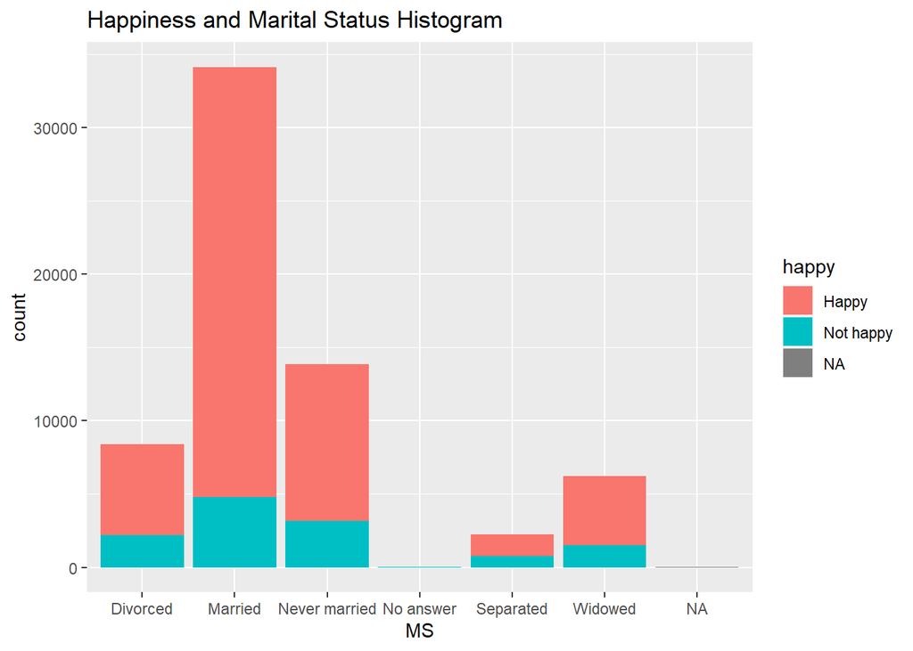

```r
happinessDat <- dat %>%
  mutate(happy = ifelse(Happiness == "Very happy" | Happiness == "Pretty happy", "Happy", "Not happy"))

ggplot(happinessDat, aes(MS)) + geom_histogram(stat="count", aes(fill=happy)) + labs(title = "Happiness and Marital Status Histogram")
```

```r
statusHappy1<- happinessDat %>%
  select(MS, happy) %>%
  group_by(MS) %>%
  summarise(number = n())
statusHappy1
```

```
## # A tibble: 7 x 2
##   MS            number
##   <chr>          <int>
## 1 Divorced        8379
## 2 Married        34129
## 3 Never married  13837
## 4 No answer         27
## 5 Separated       2242
## 6 Widowed         6200
## 7 <NA>               2
```

```r
statusHappy2<- happinessDat %>%
  select(MS, happy) %>%
  group_by(happy) %>%
  summarise(number = n())
statusHappy2
```

```
## # A tibble: 3 x 2
##   happy     number
##   <chr>      <int>
## 1 Happy      52386
## 2 Not happy  12428
## 3 <NA>           2
```

3. It seems that for every different marital status type, the number of happy people is greater than those that are not happy. The histograms displays that a large number of married people are happy. By looking at the histogram, it appears that married people have the highest ratio of being happy to unhappy. There are far few responses from separated and widowed respondents, but their numbers of happiness are still far higher than their numbers of unhappy people. I believe that being married has an increased correlation of being happy, but all of the other marital statuses are similar in overall distribution to married people.

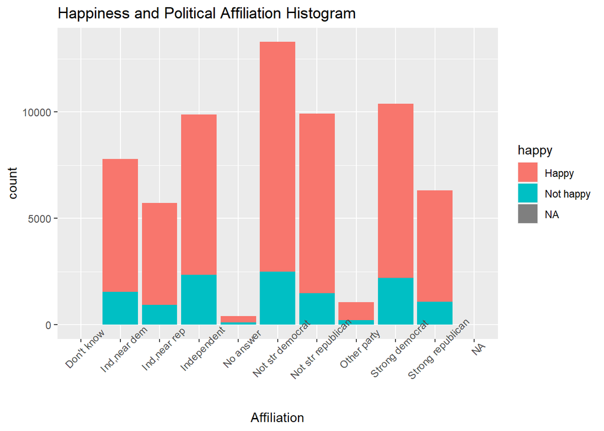

```r
ggplot(happinessDat, aes(Affiliation)) + geom_histogram(stat="count", aes(fill=happy)) + labs(title = "Happiness and Political Affiliation Histogram") + theme(axis.text.x =element_text(angle=45))
```

```r
statusHappy3 <- happinessDat %>%
  select(Affiliation, happy, MS) %>%
  group_by(Affiliation, happy, MS) %>%
  summarise(number = n())
sh1 <- statusHappy3 %>% arrange(desc(number))
sh1
```

```
## # A tibble: 113 x 4
## # Groups:   Affiliation, happy [21]
##    Affiliation        happy MS            number
##    <chr>              <chr> <chr>          <int>
##  1 Not str democrat   Happy Married         5974
##  2 Not str republican Happy Married         5254
##  3 Strong democrat    Happy Married         4146
##  4 Independent        Happy Married         3933
##  5 Strong republican  Happy Married         3407
##  6 Ind,near dem       Happy Married         3203
##  7 Ind,near rep       Happy Married         2826
##  8 Not str democrat   Happy Never married   2261
##  9 Independent        Happy Never married   1822
## 10 Ind,near dem       Happy Never married   1670
## # ... with 103 more rows
```

```r
statusHappy3
```

```
## # A tibble: 113 x 4
## # Groups:   Affiliation, happy [21]
##    Affiliation  happy     MS            number
##    <chr>        <chr>     <chr>          <int>
##  1 Don't know   Happy     Married            6
##  2 Don't know   Happy     Never married      1
##  3 Don't know   Happy     Widowed            1
##  4 Don't know   Not happy Never married      1
##  5 Don't know   Not happy Separated          1
##  6 Don't know   Not happy Widowed            1
##  7 Ind,near dem Happy     Divorced         803
##  8 Ind,near dem Happy     Married         3203
##  9 Ind,near dem Happy     Never married   1670
## 10 Ind,near dem Happy     No answer          1
## # ... with 103 more rows
```

4. The histogram is displaying that Independents are have a large proportion of unhappy people to happy people. Their numbers are not as great as Strong democrat and Not strong democrat, however their number of unhappy people is close in comparison while their number of happy people is considerably lower than the two democrat affiliations. Looking through the summarized tables, no response for political affiliation has very few responses, but their number of happy people to unhappy people is close to each other. There are a little more than 3 times as many happy people who responded with No response than unhappy people. This closer distribution seems to be most prevalent in No response than any of the other political affiliations.

```r
#dat$EducationYears <- as.numeric(dat$Education)

#AffEduMean <- dat %>% group_by(Affiliation) %>%
 # summarise(meanEducation = mean(EducationYears, na.rm=TRUE)) %>%
 # arrange(desc(meanEducation))

#AffEduMedian <- dat %>% group_by(Affiliation) %>%
 # summarise(medianEducation = median(EducationYears, na.rm=TRUE)) %>%
#  arrange(desc(medianEducation))

#AffEduMean

#dat <- full_join(dat, AffEduMedian, by='Affiliation')
```

```r
MSE <- dat %>% group_by(MS) %>%
  summarise(meanMSE = mean(EducationYears, na.rm = TRUE),
            medianMSE = median(EducationYears, na.rm = TRUE),
            sdMSE = sd(EducationYears, na.rm = TRUE),
            count = n())
MSE
```

```
## # A tibble: 7 x 5
##   MS            meanMSE medianMSE sdMSE count
##   <chr>           <dbl>     <dbl> <dbl> <int>
## 1 Divorced         13.1        13  2.91  8379
## 2 Married          13.0        12  3.19 34129
## 3 Never married    13.4        13  2.85 13837
## 4 No answer        15.5        16  2.84    27
## 5 Separated        11.9        12  3.28  2242
## 6 Widowed          11.2        12  3.49  6200
## 7 <NA>            NaN          NA NA        2
```

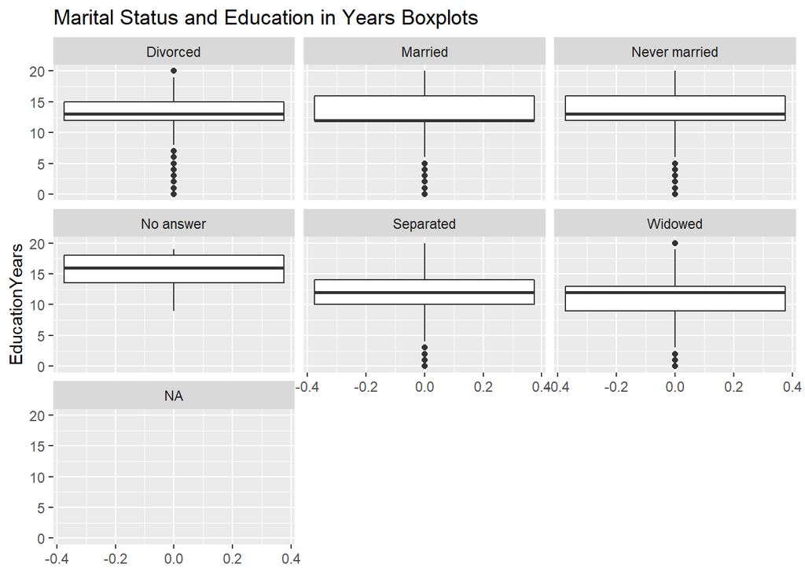

```r
boxplotMSE <- ggplot(dat, aes(y=EducationYears)) +
    geom_boxplot() +
    facet_wrap(vars(MS)) +
    labs(title = "Marital Status and Education in Years Boxplots")
boxplotMSE
```

5. A perplexing feature from this specific exploration is when looking at the “No answer” response. It is small group of only 27 responses, however their mean and median values are considerably higher than all other groups. Also, their standard deviation is lowest in comparison to other responses. With the total responses being low, this outcome is not hard to believe, but it is still an interesting result. The response with the second highest mean in education was “Never married”. This is a believable result, because people who are not married will likely have more freedom to further their education more so than people who are married who would likely make education decisions based around other people’s lives, their spouse and possibly children, before their own.

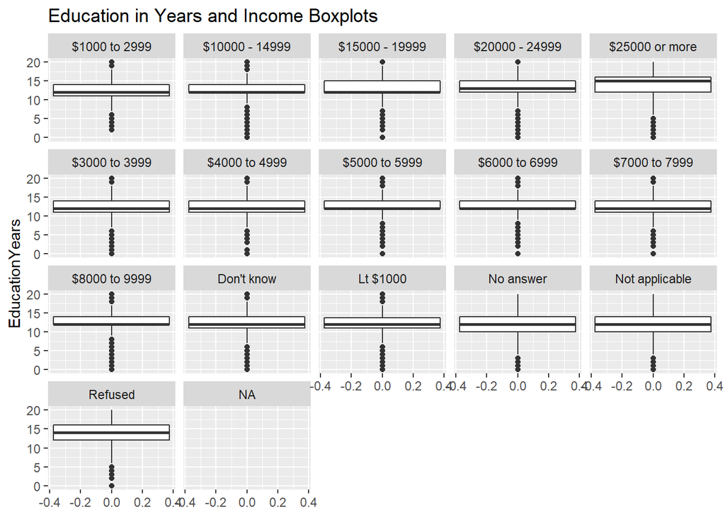

```r
boxplotMSI <- ggplot(dat, aes(y=EducationYears)) +
    geom_boxplot() +
    facet_wrap(vars(Income)) +
    labs(title = "Education in Years and Income Boxplots")
boxplotMSI
```

```r
EI <- dat %>% group_by(Income) %>%
  summarise(meanMSI = mean(EducationYears, na.rm = TRUE),
            medianMSI = median(EducationYears, na.rm = TRUE),
            sdMSI = sd(EducationYears, na.rm = TRUE),
            count = n()) %>%
            arrange(desc(count))
EI
```

```
## # A tibble: 17 x 5
##    Income         meanMSI medianMSI sdMSI count
##    <chr>            <dbl>     <dbl> <dbl> <int>
##  1 Not applicable    11.8        12  3.31 23184
##  2 $25000 or more    14.7        15  2.77 14957
##  3 $10000 - 14999    12.7        12  2.60  4876
##  4 $15000 - 19999    13.1        12  2.72  3838
##  5 $20000 - 24999    13.4        13  2.71  3838
##  6 Refused           13.8        14  2.95  2163
##  7 $1000 to 2999     12.3        12  2.64  1865
##  8 $8000 to 9999     12.6        12  2.71  1745
##  9 Lt $1000          12.1        12  2.82  1306
## 10 $3000 to 3999     12.3        12  2.88  1243
## 11 No answer         12.0        12  3.41  1122
## 12 $5000 to 5999     12.5        12  2.67  1091
## 13 $4000 to 4999     12.3        12  2.64  1055
## 14 $6000 to 6999     12.4        12  2.77   993
## 15 $7000 to 7999     12.3        12  2.73   981
## 16 Don't know        12.1        12  3.34   557
## 17 <NA>             NaN          NA NA        2
```

5. It is not surprising that respondents who answer “25000 or more” for their income appear to typically have the largest income typically. This is due to multiple reasons in my opinion. First, more affluent families typically push their children to further their education and they usually have the resources to support them more financially than less affluent families. Second, more people have been attending university in the last few decades. Given that the typical incomes of this last decade or so is greater than what is was 30 years or more ago, that would lead to more respondents falling into the “25000 or more” response. It is interesting that the “Not applicable” response was used most frequently. The “Not applicable” response has the lowest mean education in years. This could be due to less educated respondents not feeling secure in disclosing their income bracket or that they don’t feel that that is something others should know about.

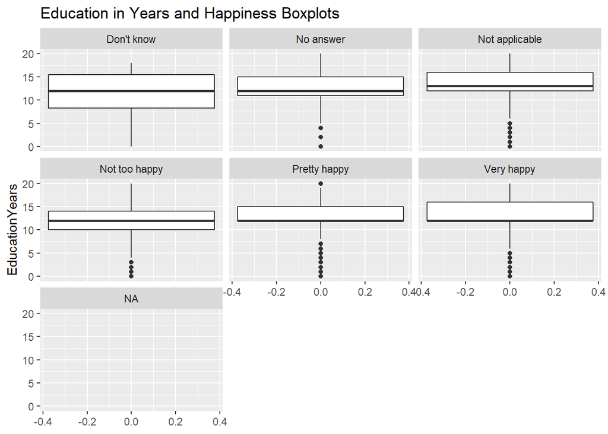

```r
boxplotHE <- ggplot(dat, aes(y=EducationYears)) +
    geom_boxplot() +
    facet_wrap(vars(Happiness)) +
    labs(title = "Education in Years and Happiness Boxplots")
boxplotHE
```

```r
HE <- dat %>% group_by(Happiness) %>%
  summarise(meanHE = mean(EducationYears, na.rm = TRUE),
            medianHE = median(EducationYears, na.rm = TRUE),
            sdHE = sd(EducationYears, na.rm = TRUE),
            count = n()) %>%
            arrange(desc(meanHE))
HE
```

```
## # A tibble: 7 x 5
##   Happiness      meanHE medianHE  sdHE count
##   <chr>           <dbl>    <dbl> <dbl> <int>
## 1 Not applicable   13.4       13  3.02  4383
## 2 Very happy       13.1       12  3.24 18823
## 3 Pretty happy     12.9       12  3.08 33563
## 4 No answer        12.4       12  3.80   338
## 5 Not too happy    11.9       12  3.32  7668
## 6 Don't know       11.6       12  4.13    39
## 7 <NA>            NaN         NA NA        2
```

6. How is Happiness Related to Education? Are more happy people well educated? It seems that “Not applicable” respondents have a greater mean education in years. This could be due the fact that more educated people will think over the question and come to a decision that they aren’t overall one feeling of happiness or the other. They may also think the question is not important. It also seems that more educated people are happier whereas “Not too happy” respondents have a mean education in years lower than most other responses.